# Pendel

Milena Mensching Justus Weyers

2022-12-01

# Versuch 1

## Ziel

Bestimmung der Erdbeschleunigung $g$.

## Materialien

- Stativ
- Pendel aus Angelschnur und Metallzylinder
- Maßband
- Messschieber
- Klebeband
- Stoppuhr

## Versuchsaufbau

- Aufstellung des Stativs, Befestigung oberhalb des Tisches
- Befestigung des Maßbandes am Stativ mit Hilfe von Klebeband

[figure not shown]

Versuchsaufbau 1

## Durchführung

Die Pendellänge wurde bestimmt, indem das obere und das untere Ende des Fadens am Maßband abgelesen und die Differenz berechnet wurde. Es wurde auch darauf geachtet, die Distanz von der Pendeloberkante bis zum Massenschwerpunkt des Pendels dazuzurechnen. Dazu wurde die Massenverteilung in dem Metallzylinder-Gewicht als homogen angenommen und die Höhe des Zylinders mit dem Messschieber ausgemessen. Die zu der Fadenlänge zu addierende Länge entspricht dann der halben Zylinderhöhe.
Die Unsicherheit der Pendellänge setzt sich aus den zu diesen Messungen zugehörigen Messunsicherheiten zusammen:
$$\begin{align}
u_L &= \sqrt{u_{Maßband}^2+u_{Maßband}^2+u_{Zylinderhöhe}^2}\\
&= \sqrt{2 \cdot u_{Maßband}^2+u_{Zylinderhöhe}^2}\\
&= \sqrt{2 \cdot
(\frac{10^{-3}m}{2\sqrt{6}})^2+(\frac{10^{-4}m}{2\sqrt{6}})^2}\\
&\approx 2,9*10^{-4}m\\
\end{align}$$

```r
sqrt(2*(((10**-3)/(2*sqrt(6)))**2)+((10**-4)/(2*sqrt(6)))**2)
```

```
## [1] 0.0002893959
```

[figure not shown]

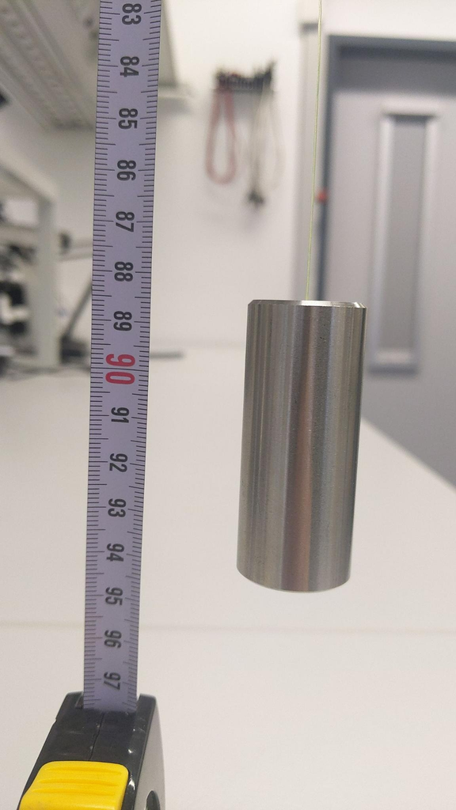

Es werden insgesamt 5 Messungen mit insgesamt 10 Periodendurchläufen durchgeführt. Die Zeit wird zum Zeitpunkt der maximalen Geschwindigkeit sowohl gestartet als auch gestoppt, um die Reaktionszeit möglichst kurz zu halten. Nach der Messung wurde zur weiteren Berechnung der Mittelwert der 10-Periodendauern ermittelt.

## Fehlerquellen

Beim Auslenken des Pendels gibt es **unregelmäßige Bewegungen (Wackeln)**, die entgegen der Pendelbahn laufen.

Beim Abmessen der Pendellänge ist der **personenbezogene Ablesefehler** zu erwähnen. Diesen versuchten wir weitestgehend zu eliminieren, indem nur eine Person eine vollständige Datenreihe aufnahm.

Außerdem verlängert die **Reaktionszeit** sowohl bei Start als auch bei Stopp der Messung tendenziell die gemessene Periodendauer. Um diesen Fehler möglichst gering zu halten, wurden meherere Periodendurchläufe (10) gemessen und die Periodendauer danach gemittelt. Auch hier nahm nur eine Person die Datenreihe auf, um die Reaktionszeit ähnlich zu halten.

Folgende Annahmen mussten darüber hinaus getroffen werden:

- Bewegung des Pendelkörpers und des Fadens verläuft reibungsfrei
- Masse des Fadens wird vernachlässigt
- Der Pendelkörper wird nur um eine kleine Strecke ausgelenkt

## Messungen

```r
Werte <- read.csv("Daten/Daten.csv", sep = ";", dec = ",")
colnames(Werte) <- c("A","M1","M2","M3","M4","M5","M6","M7")
Werte <- Werte[,1:8]
```

## Auswertung

Die Periodendauer $T$ wird wie folgt berechnet:
$$\begin{equation*}
\begin{split}
T&= \frac{T_{10T}}{n}\\
T&= \frac{18,78s}{10}\\
T&= 1,878s
\end{split}
\end{equation*}$$

Die Standardabweichung berechnet sich wie folgt:
$$\begin{equation*}
\begin{split}
\sigma_x &= \sqrt{\frac{1}{n-1} \sum_{i=1}^n (T_i -
\overline{T})^2}\\
\sigma_x &= \sqrt{\frac{1}{4} \sum_{i=1}^5 (T_i - \overline{T})^2}\\
\sigma_x &\approx 6,686*10^{-2}s
\end{split}
\end{equation*}$$

```r
sd(Werte$M1[4:8])
```

```
## [1] 0.06685806
```

Standardabweichung des Mittelwerts:

$$\begin{equation*}
\begin{split}
\sigma_{\overline{T}}&=\frac{\sigma_x * t }{\sqrt{n}}\\
\sigma_{\overline{T}}&=\frac{6,686*10^{-2}s * 1,15 }{\sqrt{5}}\\
\sigma_{\overline{T}}&\approx 0,034s
\end{split}
\end{equation*}$$
mit $t=$ Studentfaktor

```r
(6.686*(10**-2)*1.15)/sqrt(5)
```

```
## [1] 0.03438581
```

Messunsicherheit der digitalen Stoppuhr:
$$\begin{equation*}
\begin{split}
u_{Stoppuhr}&= \frac{a}{2\sqrt{3}}\\
u_{Stoppuhr}&= \frac{0,01s}{2\sqrt{3}}\\
u_{Stoppuhr}&\approx 0,0029s
\end{split}
\end{equation*}$$

```r
0.01/(2*sqrt(3))
```

```
## [1] 0.002886751
```

Die Messunsicherheit der Periodendauer $u_T$ setzt sich aus der Unsicherheit der digitalen Stoppuhr sowie der Standardabweichung des Mittelwerts der Perioden zusammen:

$$\begin{equation*}
\begin{split}
u_T &= \sqrt{u_{Stoppuhr}^2+\sigma_{\overline{T}}^2}\\
u_T &= \sqrt{0,0029s^2+0,034s^2}\\
u_T &= 0,034s
\end{split}
\end{equation*}$$

```r
sqrt((0.0029**2) + (0.034**2))
```

```
## [1] 0.03412345
```

$T$ ergibt sich damit zu $T = (1,878 \pm 0,034)s$

Bestwert der Erdbeschleunigung $g$:

Aus $T=2*\pi*\sqrt{\frac{l}{g}}$ ergibt sich:

$$\begin{equation*}
\begin{split}
g&=\frac{4*\pi^2*l}{T^2}\\
g&=\frac{4*\pi^2*0,8744m}{(1,878s)^2}\\
g&\approx 9.79 \frac{m}{s^2}
\end{split}
\end{equation*}$$

Mit $l = 0,8744m$  
und $T = 1,878s$

```r
(4*pi**2*0.8744)/(1.878**2)
```

```
## [1] 9.787656
```

Messunsicherheit der Erdbeschleunigung $g$:
$$\begin{equation*}
\begin{split}
u_g&=\sqrt{(\frac{\delta g}{\delta T}*u_T)^2+(\frac{\delta g}{\delta
l}*u_l)^2}\\
u_g&=\sqrt{(\frac{-8*\pi^2*l}{T^3}*u_T)^2+(\frac{4*\pi^2}{T^2}*u_l)^2}\\
\\
u_g&=\sqrt{(\frac{-8*\pi^2*0,8744m}{(1,878s)^3}*0,034s)^2+(\frac{4*\pi^2}{(1,878s)^2}*2,9*10^{-4})^2}\\
u_g&\approx \pm 0,35 \frac{m}{s^2}
\end{split}
\end{equation*}$$

```r
sqrt((((-8*pi**2*0.8744)/1.878**3)*0.034)**2+(((4*pi**2)/1.878**2)*2.9*10**(-4))**2)
```

```
## [1] 0.3544135
```

## Interpretation

Der experimentell bestimmte Wert für die Erdbeschleunigung $g$ liegt bei:

$g=(9,79\pm 0,35)\frac{m}{s^2}$

Das Intervall beinhaltet den Literaturwert von $g=9,81\frac{m}{s^2}$.

# Versuch 2

Der zweite Versuch läuft analog zum ersten Versuch. Allerdings werden statt nur einer Messreihe 5 verschiedene - jeweils mit einer anderen Fadenlänge - gemessen. Um die Pendellängen zu variieren wurde der Faden für kürzere Fadenlängen mit Klebeband am Zylinder stückchenweise festgeklebt. Für längere Pendellängen wurden weitere Stücke Angelschnur an das Pendel geknotet.

## Fehlerquellen

Die Fehlerquellen sind ebenfalls die selben wie beim ersten Versuch. Allerdings ist hierbei zu bemerken, dass die Reaktioszeit bei kürzeren Fadenlängen und daraus resultierenden kürzeren Periodendauern verhältnismäßig zunimmt. Auch von der Bahn abweichende Bewegungen nehmen bei kürzeren Pendellängen zu. Auch ist nicht unterscuht, wie sich Klebeband bzw. Knoten im Faden auf das Pendelverhalten auswirken.